# Tabla de contenidos

- 1. Objetivos del estudio
- 2. Dataset y variables
- 3. Metodología
- 4. Análisis Exploratorio
  - 4.1 Análisis Descriptivo
  - 4.2 Histogramas y gráficas
    - 4.2.1 Histograma de las asignaturas
    - 4.2.2 Distribución de las notas
    - 4.2.3 Ánalisis de la asimetría de las asignaturas
    - 4.2.4 Distribución numérica del dataset
    - 4.2.5 Análisis bivariante entre asignaturas
    - 4.1.6 Exámenes realizados por género
    - 4.1.7 Media de las asignaturas por género
    - 4.1.7 Boxplots género y asignaturas
    - 4.1.8 Suspensos y Aprobados de cada asignatura
    - 4.1.9 Aprobados y Suspensos por género
    - 4.1.10 Media de las asignaturas por etnia
    - 4.1.11 Boxplots asignaturas y etnia
    - 4.1.12 Suspensos por etnia
  - 4.3 Matriz de correlación

[figure not shown]

# Análisis Exploratorio sobre el rendimiento de los estudiantes en exámenes

#### Autor: Ignacio Ruiz de Zuazu Echevarría

#### 23 de octubre de 2020

## Objetivos del estudio

El objetivo de este trabajo es el de realizar un análisis exploratorio sobre un dataset que nos aporta información acerca del rendimiento de los estudiantes en una serie de asignaturas dado una serie de características de los estudiantes como el género, la etnia y el nivel educativo de los padres entre otras. El anñalisis exploratorio se centrará en observar a partir de la representación de histogramas, las medias, los aprobados y los suspensos de cada asignatura. Estos resultados del mismo modo se agruparán por género y por etnia de los estudiantes con el objetivo de responder a las preguntas acerca de, ¿las mujeres obtienen mejoras notas que los hombres?¿que etnia es la que saca mejores notas y la que menos? Finalmente se representará la matriz de correlaciones entre las distintas asignaturas.

## Dataset y variables

El Dataset que se va a estudiar contiene 8 variables:

- El género (masculino o femenino).
- La etnia del estudiante que debido a que este dataset es de naturaleza ficticia, dividen la etnia en 5 grupos de A a E.
- Parental level of education: nivel educativo de los padres.
- lunch: precio de la comida en el colgeio, puede ser gratis/precio reducido o precio estándar.
- test preparation course: curso de preparación para los exámenes, puede estar o no completado.
- math score: nota en matemáticas.
- reading score: nota en comprensión lectora.
- writing score: nota en expresión escrita.

### Librerías que se van a emplear

```python
import pandas as pd
import numpy as np
import matplotlib.pyplot as plt
import seaborn as sns
```

### Dataset

```python
students_p = pd.read_csv('../data/01_raw.csv', delimiter = ',')
students_p.head(5)
```

|  | gender | race/ethnicity | parental level of education | lunch | test preparation course | math score | reading score | writing score |
| --- | --- | --- | --- | --- | --- | --- | --- | --- |
| 0 | female | group B | bachelor's degree | standard | none | 72 | 72 | 74 |
| 1 | female | group C | some college | standard | completed | 69 | 90 | 88 |
| 2 | female | group B | master's degree | standard | none | 90 | 95 | 93 |
| 3 | male | group A | associate's degree | free/reduced | none | 47 | 57 | 44 |
| 4 | male | group C | some college | standard | none | 76 | 78 | 75 |

```python
 students_p.tail(5)
```

|  | gender | race/ethnicity | parental level of education | lunch | test preparation course | math score | reading score | writing score |
| --- | --- | --- | --- | --- | --- | --- | --- | --- |
| 995 | female | group E | master's degree | standard | completed | 88 | 99 | 95 |
| 996 | male | group C | high school | free/reduced | none | 62 | 55 | 55 |
| 997 | female | group C | high school | free/reduced | completed | 59 | 71 | 65 |
| 998 | female | group D | some college | standard | completed | 68 | 78 | 77 |
| 999 | female | group D | some college | free/reduced | none | 77 | 86 | 86 |

Con el objetivo de facilitar el cálcuo de las gráficas y operaciones, se va a renombrar algunas de las columnas.

```python
students_p = students_p.rename(columns = {'test preparation course ': 'test_preparation_course','race/ethnicity':'race',
                                          'parental level of education':'parental_level_of_education',
                       'test preparation course':'test_preparation_course','math score':'math_score',
                       'reading score':'reading_score', 'writing score':'writing_score'})
```

## Metodología

Para el análisis exploratorio se va a tratar de, en primer lugar, observar las características de este Dataset para ver de que tipo es cada variable y si existen valores NaN que puedan comprometer este estudio. Seguidamente, mediante histogramas y cálculo numérico se evaluará desde un enfoque global los resultados de las asignaturas. En relación al apartado anterior y con el mismo procedimiento, se evaluará las notas en términos de medias, número de aprobados y de suspensos por género y por etnia. Finalmente se realizará una gráfica que represente las correlaciones entre las asignaturas.

## Análisis Exploratorio

### Análisis Descriptivo

```python
pd.DataFrame(list(students_p) ,columns = ['Columnas'])
```

|  | Columnas |
| --- | --- |
| 0 | gender |
| 1 | race |
| 2 | parental_level_of_education |
| 3 | lunch |
| 4 | test_preparation_course |
| 5 | math_score |
| 6 | reading_score |
| 7 | writing_score |

```python
students_p.info()
```

```
<class 'pandas.core.frame.DataFrame'>
RangeIndex: 1000 entries, 0 to 999
Data columns (total 8 columns):
 #   Column                       Non-Null Count  Dtype
---  ------                       --------------  -----
 0   gender                       1000 non-null   object
 1   race                         1000 non-null   object
 2   parental_level_of_education  1000 non-null   object
 3   lunch                        1000 non-null   object
 4   test_preparation_course      1000 non-null   object
 5   math_score                   1000 non-null   int64
 6   reading_score                1000 non-null   int64
 7   writing_score                1000 non-null   int64
dtypes: int64(3), object(5)
memory usage: 62.6+ KB
```

Vemos que hay 5 variables que son objetos correspondientes al sexo, la raza o etnia, y otras 3 varaibles correspondientes a las distintas puntuaciones que han conseguido los alumnos en matemáticas, comprensión lectora y prueba escrita.

```python
students_p.describe()
```

|  | math_score | reading_score | writing_score |
| --- | --- | --- | --- |
| count | 1000.00000 | 1000.000000 | 1000.000000 |
| mean | 66.08900 | 69.169000 | 68.054000 |
| std | 15.16308 | 14.600192 | 15.195657 |
| min | 0.00000 | 17.000000 | 10.000000 |
| 25% | 57.00000 | 59.000000 | 57.750000 |
| 50% | 66.00000 | 70.000000 | 69.000000 |
| 75% | 77.00000 | 79.000000 | 79.000000 |
| max | 100.00000 | 100.000000 | 100.000000 |

Se muestran los estadísiticos correspondientes a las distintas puntuaciones en las distintas pruebas. Observamos que hay 1000 notas en cada una de los examenes con una media parecida entre los 66 y 70 puntos.

```python
students_p.shape # filas y columnas
```

```
(1000, 8)
```

```python
students_p.index
```

```
RangeIndex(start=0, stop=1000, step=1)
```

```python
students_p.select_dtypes('object').nunique()
```

```
gender                         2
race                           5
parental_level_of_education    6
lunch                          2
test_preparation_course        2
dtype: int64
```

Se observa el número de variables distintas para cada columna de carácter objeto. vemos que tanto lunch como test preparation course únicamente contienen dos tipos de valores.

```python
students_p.lunch.value_counts()
```

```
standard        645
free/reduced    355
Name: lunch, dtype: int64
```

```python
students_p.test_preparation_course.value_counts()
```

```
none         642
completed    358
Name: test_preparation_course, dtype: int64
```

Dado que los valores de dichas variables no mantienen valores representativos para el estudio, se eliminarán de la dataframe que se empleará en el estudio.

```python
students_p = students_p.drop(['lunch', 'test_preparation_course'], axis=1)
```

```python
pd.DataFrame(students_p.isna().sum(), columns = ['Valores NaN'])
```

|  | Valores NaN |
| --- | --- |
| gender | 0 |
| race | 0 |
| parental_level_of_education | 0 |
| math_score | 0 |
| reading_score | 0 |
| writing_score | 0 |

No hay valores del tipo NaN en ninguna de las variables.

```python
students_p.to_csv('02_intermidiate.csv')
```

## Histogramas y gráficas

### Histograma de las asignaturas

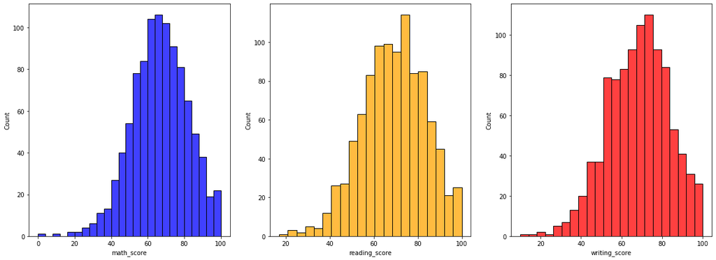

```python
figura, (ax1, ax2, ax3) = plt.subplots(1, 3, figsize = (20,7))
sns.histplot(students_p, ax=ax1, x="math_score", color = 'blue')
sns.histplot(students_p, ax=ax2, x="reading_score", color = 'orange')
sns.histplot(students_p, ax=ax3, x="writing_score", color = 'red')
```

Observamos que las 3 asignaturas sigue una distribución similar, con valores concentrados entre las puntuaciones 60 y 70. Se puede ver que en matemáticas a diferencia de las otras asignaturas, mantiene una mayor frecuencia entre los 40 y 50. Los exámenes de expresión escrita contiene una mayor frecuencia entre los 60 y 80 puntos a diferencia de los exámenes de matemáticas y comprensión lectora.

### Distribución de las notas

```
count    1000.00000
mean       66.08900
std        15.16308
min         0.00000
25%        57.00000
50%        66.00000
75%        77.00000
max       100.00000
Name: math_score, dtype: float64
```

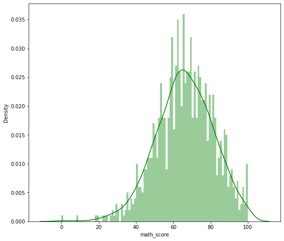

```python
# En matemáticas
print(students_p['math_score'].describe())
plt.figure(figsize=(9, 8))
sns.distplot(students_p['math_score'], color='g', bins=100, hist_kws={'alpha': 0.4});
```

```
count    1000.000000
mean       69.169000
std        14.600192
min        17.000000
25%        59.000000
50%        70.000000
75%        79.000000
max       100.000000
Name: reading_score, dtype: float64
```

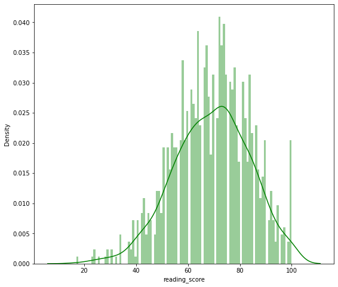

```python
# En comprensión lectora
print(students_p['reading_score'].describe())
plt.figure(figsize=(9, 8))
sns.distplot(students_p['reading_score'], color='g', bins=100, hist_kws={'alpha': 0.4});
```

```
count    1000.000000
mean       68.054000
std        15.195657
min        10.000000
25%        57.750000
50%        69.000000
75%        79.000000
max       100.000000
Name: writing_score, dtype: float64
```

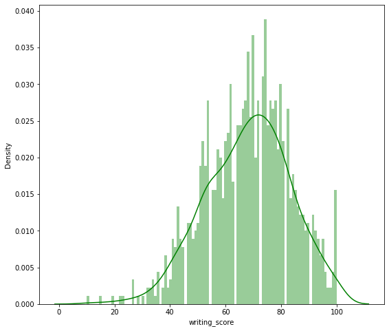

```python
# En expresión escrita
print(students_p['writing_score'].describe())
plt.figure(figsize=(9, 8))
sns.distplot(students_p['writing_score'], color='g', bins=100, hist_kws={'alpha': 0.4});
```

### Ánalisis de la asimetría de las asignaturas

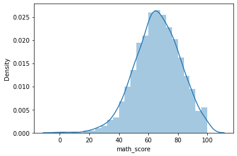

```python
sns.distplot(students_p['math_score'])
```

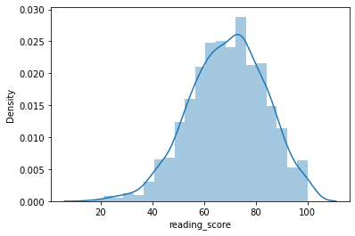

```python
sns.distplot(students_p['reading_score'])
```

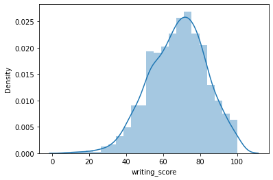

```python
sns.distplot(students_p['writing_score'])
```

### Distribución numérica del dataset

```python
list(set(students_p.dtypes.tolist()))
students_p_num = students_p.select_dtypes(include = ['float64', 'int64'])
students_p_num.head()
```

|  | math_score | reading_score | writing_score |
| --- | --- | --- | --- |
| 0 | 72 | 72 | 74 |
| 1 | 69 | 90 | 88 |
| 2 | 90 | 95 | 93 |
| 3 | 47 | 57 | 44 |
| 4 | 76 | 78 | 75 |

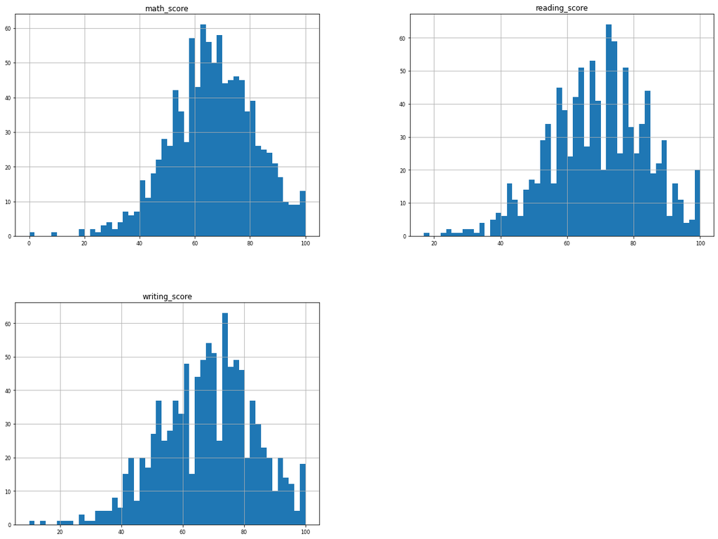

```python
students_p_num.hist(figsize=(20, 15), bins=50, xlabelsize=8, ylabelsize=8);
```

### Análisis bivariante entre asignaturas

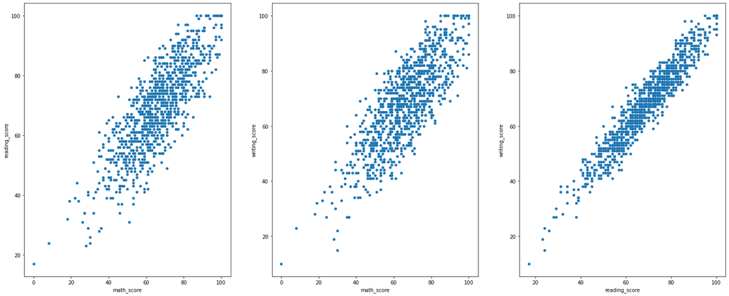

```python
figura, (ax1, ax2, ax3) = plt.subplots(1, 3, figsize = (25,10))
students_p.plot.scatter(ax = ax1, x="math_score",y="reading_score")
students_p.plot.scatter(ax = ax2, x="math_score",y="writing_score")
students_p.plot.scatter(ax = ax3, x="reading_score",y="writing_score")
```

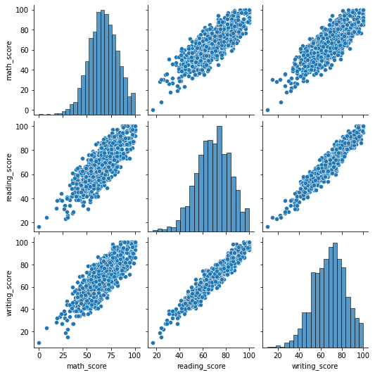

```python
sns.pairplot(data = students_p, vars=['math_score','reading_score','writing_score'])
plt.show()
```

Se observa que las asignaturas entre matemáticas y el resto son más dispersas mientras que la comprensión lectora con la expresión escrita tienen una menor dispersión.

#### Examenes realizados por género

```python
examenes_por_genero = students_p.groupby(['gender']).gender.agg(['count']).reset_index()
examenes_por_genero
```

|  | gender | count |
| --- | --- | --- |
| 0 | female | 518 |
| 1 | male | 482 |

```
[Text(0, 0, 'female'), Text(1, 0, 'male')]
```

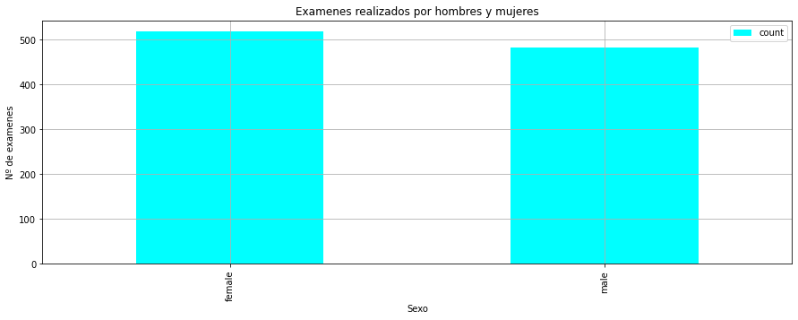

```python
figura, (ax1) = plt.subplots(1, figsize = (15, 5))
examenes_por_genero.plot(ax=ax1, kind = 'bar', color= ("cyan"), title = 'Examenes realizados por hombres y mujeres', grid = True)
ax1.set_xlabel('Sexo')
ax1.set_ylabel('Nº de examenes')
plt.legend()
ax1.set_xticklabels(examenes_por_genero.gender)
```

Las mujeres han realizado más exámenes que los hombres. Este dato habrá que tenerlo en cuenta en futuras observaciones.

#### Media de las asignaturas por género

Calculamos las medias de todas las asignaturas y las agrupamos según el género.

```python
media_asignaturas_por_genero = students_p[["gender","math_score","reading_score","writing_score"]].groupby('gender').mean()
media_asignaturas_por_genero
```

| gender | math_score | reading_score | writing_score |
| --- | --- | --- | --- |
| female | 63.633205 | 72.608108 | 72.467181 |
| male | 68.728216 | 65.473029 | 63.311203 |

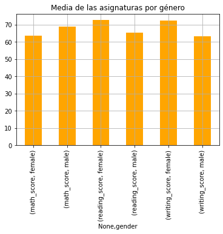

```python
media_asignaturas_por_genero.unstack().plot(kind = 'bar', color='orange', grid = True,
                                            title = 'Media de las asignaturas por género')
```

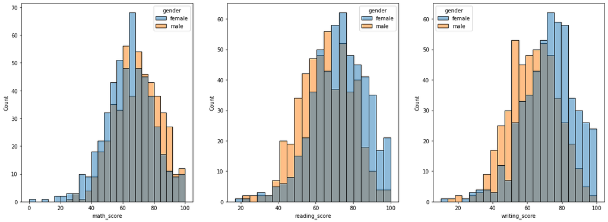

```python
figura, (ax1, ax2, ax3) = plt.subplots(1, 3, figsize = (20,7))
sns.histplot(students_p, ax=ax1, x="math_score", hue="gender")
sns.histplot(students_p, ax=ax2, x="reading_score", hue="gender")
sns.histplot(students_p, ax=ax3, x="writing_score", hue="gender")
```

### Boxplots género y asignaturas

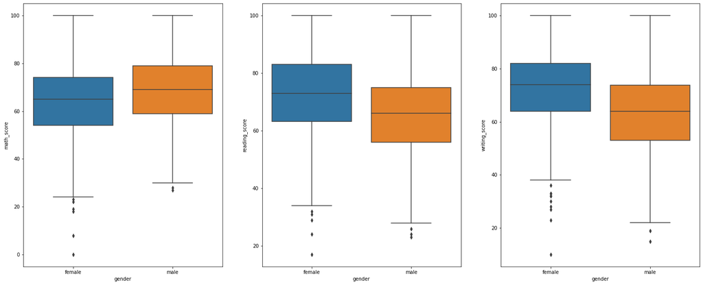

```python
figura, (ax1, ax2, ax3) = plt.subplots(1, 3, figsize = (25,10))
sns.boxplot(ax= ax1, x = students_p.gender, y  = students_p.math_score)
sns.boxplot(ax = ax2, x = students_p.gender, y  = students_p.reading_score)
sns.boxplot(ax= ax3, x = students_p.gender, y  = students_p.writing_score)
```

#### Suspensos y Aprobados de cada asignatura

```python
students_p['resultados_mates'] = np.where(students_p['math_score'] < 50, 'suspendida', 'aprobada')
students_p['resultados_reading'] = np.where(students_p['reading_score'] < 50, 'suspendida', 'aprobada')
students_p['resultados_writing'] = np.where(students_p['writing_score'] < 50, 'suspendida', 'aprobada')
```

```python
resultado_mates = students_p['resultados_mates'].value_counts()
print(resultado_mates)
resultado_reading = students_p['resultados_reading'].value_counts()
print(resultado_reading)
resultado_writing = students_p['resultados_writing'].value_counts()
print(resultado_writing)
```

```
aprobada      865
suspendida    135
Name: resultados_mates, dtype: int64
aprobada      910
suspendida     90
Name: resultados_reading, dtype: int64
aprobada      886
suspendida    114
Name: resultados_writing, dtype: int64
```

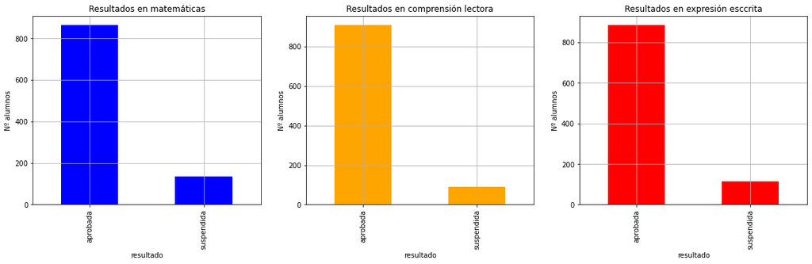

```python
figura, (ax1, ax2, ax3) = plt.subplots(1, 3, figsize = (20,5))

students_p['resultados_mates'].value_counts(dropna = False).plot(ax=ax1, kind= 'bar', color = 'blue',
                                                                 title = 'Resultados en matemáticas', grid = True)

ax1.set_xlabel('resultado')
ax1.set_ylabel('Nº alumnos');

students_p['resultados_reading'].value_counts(dropna = False).plot(ax=ax2, kind= 'bar', color = 'orange',
                                                                   title = 'Resultados en comprensión lectora', grid = True)

ax2.set_xlabel('resultado')
ax2.set_ylabel('Nº alumnos');

students_p['resultados_writing'].value_counts(dropna = False).plot(ax=ax3,kind= 'bar', color = 'red',
                                                                   title= 'Resultados en expresión esccrita', grid = True)

ax3.set_xlabel('resultado')
ax3.set_ylabel('Nº alumnos');
```

En esta gráfica podemos ver que la asignatura con más aprobados es la de comprensión lectora y por lo tanto es la que menos suspensos tiene. La asignatura con menos aprobados y por consiguiente más suspensos es la de matemáticas a pesar de que la asignatura de expresión escrita se mantiene con valores cercanos.

#### Aprobados y Suspensos por género

```python
resultados_mates_genero = students_p.iloc[:,[0,6]]
resultados_mates_genero = pd.DataFrame(resultados_mates_genero.groupby(['gender']).resultados_mates.value_counts())

resultados_reading_genero = students_p.iloc[:,[0,7]]
resultados_reading_genero = pd.DataFrame(resultados_reading_genero.groupby(['gender']).resultados_reading.value_counts())

resultados_writing_genero = students_p.iloc[:,[0,8]]
resultados_writing_genero = pd.DataFrame(resultados_writing_genero.groupby(['gender']).resultados_writing.value_counts())
```

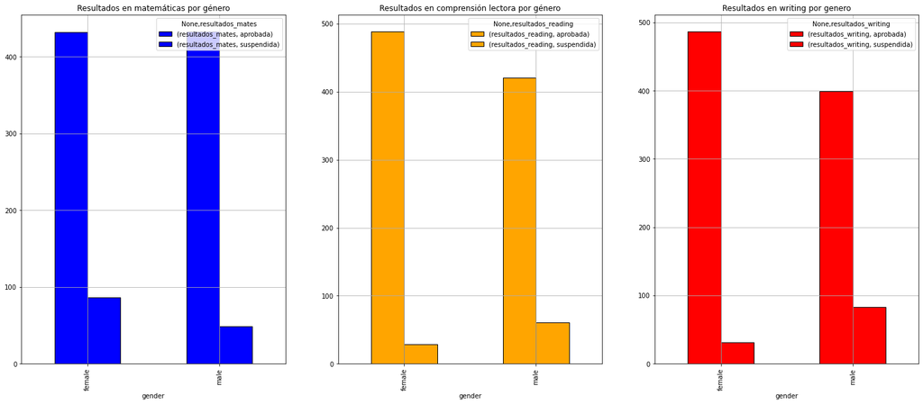

```python
figura, (ax1, ax2, ax3) = plt.subplots(1, 3, figsize = (25,10))

resultados_mates_genero.unstack().plot(ax = ax1, kind = 'bar', color='blue', edgecolor = 'black', grid = True,
                                      title = 'Resultados en matemáticas por género');

resultados_reading_genero.unstack().plot(ax = ax2, kind = 'bar', color='orange', edgecolor = 'black', grid = True,
                                        title = 'Resultados en comprensión lectora por género');

resultados_writing_genero.unstack().plot(ax = ax3, kind = 'bar', color='red', edgecolor = 'black', grid = True,
                                        title = 'Resultados en writing por genero' );
```

```python
print(resultados_mates_genero)
print(resultados_reading_genero)
print(resultados_writing_genero)
```

```
                         resultados_mates
gender resultados_mates
female aprobada                       432
       suspendida                      86
male   aprobada                       433
       suspendida                      49
                           resultados_reading
gender resultados_reading
female aprobada                           489
       suspendida                          29
male   aprobada                           421
       suspendida                          61
                           resultados_writing
gender resultados_writing
female aprobada                           487
       suspendida                          31
male   aprobada                           399
       suspendida                          83
```

A partir de estos resultados vemos que en cuanto a matemáticas, tanto hombres como mujeres se mantienen parejos en el número de aprobados y en los suspensos, las mujeres casi doblan al número de suspensos de los hombres. Tenemos que tener en cuenta que las mujeres han realizado más exámenes que los hombres, por ello hay que valorarlo en términos porcentuales y resultado igualmente nos muestra que las mujeres suspende el 16.6% de los exámenes mientras los hombres lo hacen en un 10%. En cuanto a la comprensión lectora, siguiendo el criterio anterior, el 5.58% de las mujeres suspenden esta asignatura mientras que los hombres lo hacen en un 12.6%. En expresión escrita los susoensos serían de 17.2% y 6% entre hombres y mujeres respectivamente.

#### Media de las asignaturas por etnia

```python
media_asignaturas_por_etnia = students_p[["race","math_score","reading_score","writing_score"]].groupby('race').mean()
media_asignaturas_por_etnia
```

| race | math_score | reading_score | writing_score |
| --- | --- | --- | --- |
| group A | 61.629213 | 64.674157 | 62.674157 |
| group B | 63.452632 | 67.352632 | 65.600000 |
| group C | 64.463950 | 69.103448 | 67.827586 |
| group D | 67.362595 | 70.030534 | 70.145038 |
| group E | 73.821429 | 73.028571 | 71.407143 |

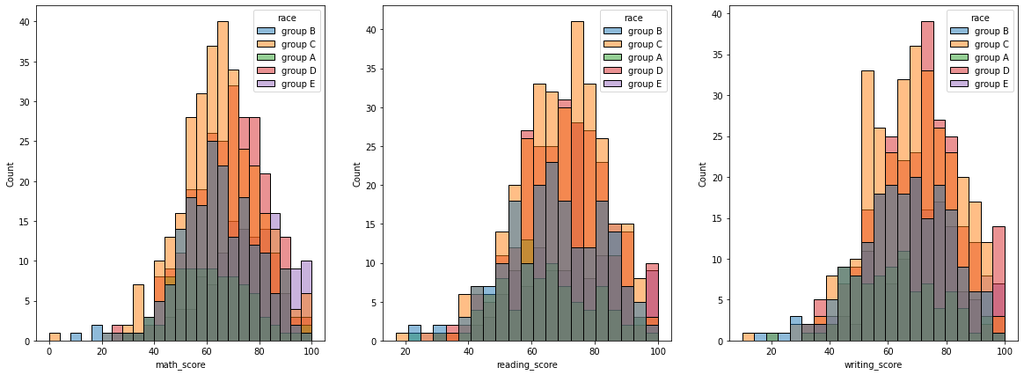

```python
figura, (ax1, ax2, ax3) = plt.subplots(1, 3, figsize = (20,7))
sns.histplot(students_p, ax=ax1, x="math_score", hue="race")
sns.histplot(students_p, ax=ax2, x="reading_score", hue="race")
sns.histplot(students_p, ax=ax3, x="writing_score", hue="race")
```

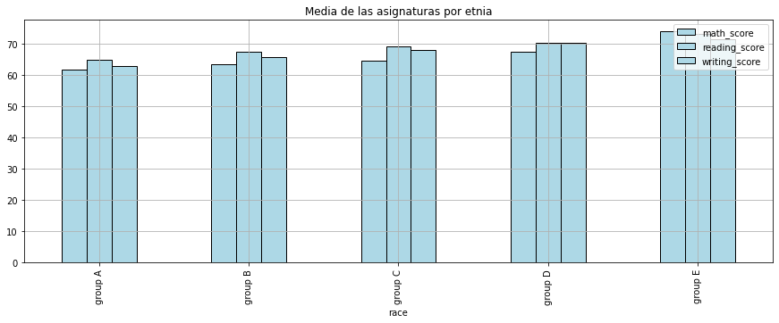

```python
media_asignaturas_por_etnia.plot(kind = 'bar', color='lightblue', edgecolor = 'black', figsize=(15,5), grid = True, title= 'Media de las asignaturas por etnia')
```

Podemos observar un orden ascendente de las medias de todas las asigntauras y en cuanto a la etnia del estudiante siendo la etnia A la que menos rendimiento ofrece y la E la que más rendimiento ofrece. Podemos ver que la etnia D tiene medias parecidas tanto en comprensión lectora como expresión escrita y los de la etnia E tiene medias parecidas en matemáticas y en comprensión lectora.

### Boxplots asignaturas y etnia

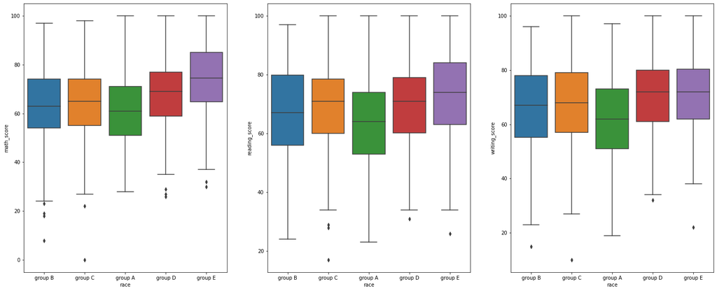

```python
figura, (ax1, ax2, ax3) = plt.subplots(1, 3, figsize = (25,10))
sns.boxplot(ax= ax1, x = students_p.race, y  = students_p.math_score)
sns.boxplot(ax = ax2, x = students_p.race, y  = students_p.reading_score)
sns.boxplot(ax= ax3, x = students_p.race, y  = students_p.writing_score)
```

#### Suspensos por etnia

```python
resultados_mates_etnia = students_p.iloc[:,[1,6]]
resultados_mates_etnia = pd.DataFrame(resultados_mates_etnia.groupby(['race']).resultados_mates.value_counts())

resultados_reading_etnia = students_p.iloc[:,[1,7]]
resultados_reading_etnia = pd.DataFrame(resultados_reading_etnia.groupby(['race']).resultados_reading.value_counts())

resultados_writing_etnia = students_p.iloc[:,[1,8]]
resultados_writing_etnia = pd.DataFrame(resultados_writing_etnia.groupby(['race']).resultados_writing.value_counts())
```

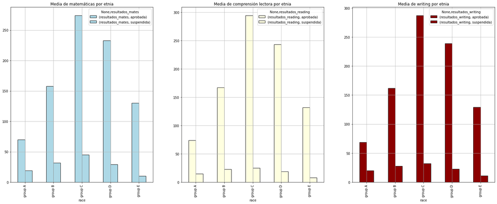

```python
figura, (ax1, ax2, ax3) = plt.subplots(1, 3, figsize = (27,10))

resultados_mates_etnia.unstack().plot(ax = ax1,kind = 'bar', color='lightblue', edgecolor = 'black', grid = True,
                                       title= 'Media de matemáticas por etnia');

resultados_reading_etnia.unstack().plot(ax = ax2, kind = 'bar', color='lightyellow', edgecolor = 'black',
                                        grid = True, title= 'Media de comprensión lectora por etnia');

resultados_writing_etnia.unstack().plot(ax = ax3, kind = 'bar', color='darkred', edgecolor = 'black',
                                        grid = True, title= 'Media de writing por etnia');
```

```python
print(resultados_mates_etnia)
print(resultados_reading_etnia)
print(resultados_writing_etnia)
```

```
                          resultados_mates
race    resultados_mates
group A aprobada                        70
        suspendida                      19
group B aprobada                       158
        suspendida                      32
group C aprobada                       274
        suspendida                      45
group D aprobada                       233
        suspendida                      29
group E aprobada                       130
        suspendida                      10
                            resultados_reading
race    resultados_reading
group A aprobada                            74
        suspendida                          15
group B aprobada                           167
        suspendida                          23
group C aprobada                           294
        suspendida                          25
group D aprobada                           243
        suspendida                          19
group E aprobada                           132
        suspendida                           8
                            resultados_writing
race    resultados_writing
group A aprobada                            69
        suspendida                          20
group B aprobada                           162
        suspendida                          28
group C aprobada                           287
        suspendida                          32
group D aprobada                           239
        suspendida                          23
group E aprobada                           129
        suspendida                          11
```

A partir de estos resultados podemos ver que en proporción total de estudiantes por etnia, los del grupo A son los que menos exámenes han realizado seguido por el grupo E y los grupos que mas exámenes han realizado son los grupos C y D. Por lo tanto, al igual que en el género, habrá que estudiar estos resultados según la proporción de estudiantes de cada grupo. Los resultados de matemáticas muestran que el grupo A es el que más suspende con un 21% mientras que los del Grupo E son los que menos suspenden en esta asignatura con un 7%. Los resultados de comprensión lectora muestran resultados parecidos al anterior ya que el grupo A es el que más suspende con un 16% mientras que los del Grupo E son los que menos suspenden en esta asignatura con un 5%. Los resultados de expresión escrita no varía con los resultados anteriores puesto que el grupo A es el que más suspende con un 22% mientras que los del Grupo E son los que menos suspenden en esta asignatura con un 7%.

### Matriz de correlación

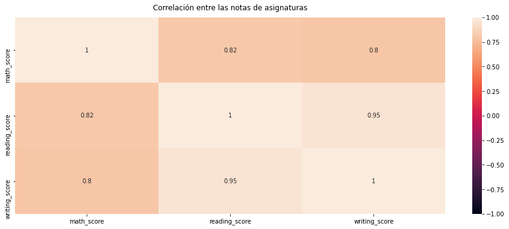

```python
asignaturas = students_p.iloc[:,[3,4,5]]
plt.figure(figsize=(16, 6))
heatmap = sns.heatmap(asignaturas.corr(), vmin=-1, vmax=1, annot=True)
heatmap.set_title('Correlación entre las notas de asignaturas', fontdict={'fontsize':12}, pad=12);
```

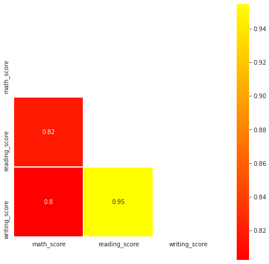

```python
corr = students_p.corr()
mask = np.zeros_like(corr)
mask[np.triu_indices_from(mask)] = True
with sns.axes_style("white"):
    f, ax = plt.subplots(figsize=(8, 8))
    ax = sns.heatmap(corr,mask=mask,square=True,linewidths=.8,cmap="autumn",annot=True)
```

Esta gráfica nos indica que cuanto más nota obtenga en una asignatura, también obtendré una nota mayor en otra asignatura. La mayor relación se encuentra en los exámenes de comprensión lectora y expresión escrita con un 0.95 posiblemente debido a que ambas provienen de una naturaleza similar. Las asignaturas que menor relación mantienen aunque positiva con un 0.8 son las asignaturas de matemáticas y expresión escrita debido posiblemente a que sean de naturaleza distinta una de otra.